# Further Graph Customizations

### Categorical axes

For categorical axes, we can use `scale_x_discrete()` or `scale_y_discrete()` functions. Some of the options when using these functions are:

- `limits`: A vector of character/string/text used to specify order of categorical names.
- `labels`: A vector of character/string/text used to rename the labels on the axis.

Here is the default plot output:

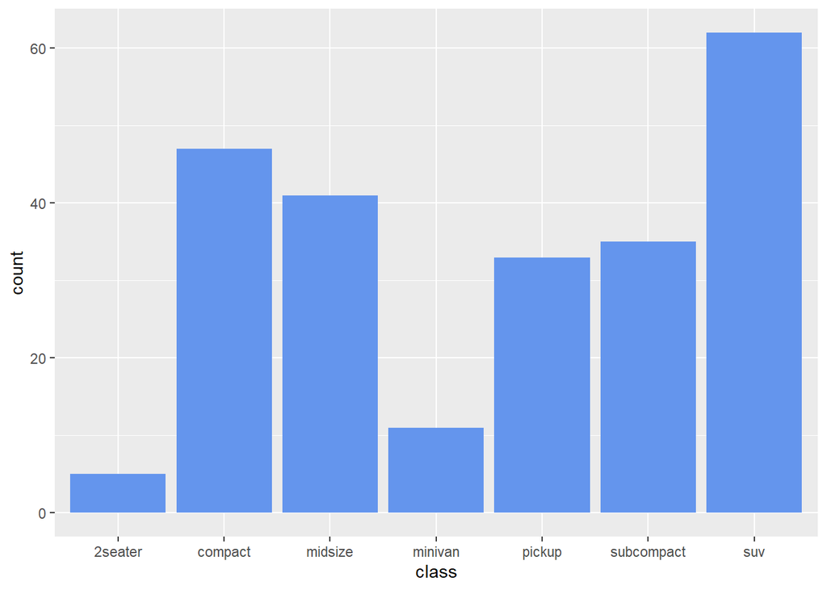

```r
ggplot(data=mpg, mapping=aes(x=class)) +
  geom_bar(fill="cornflowerblue")
```

And here is the plot output after changing the labels position using `limits` and names using `labels`. Note that the `\n` used in the `labels` represent line breaks.

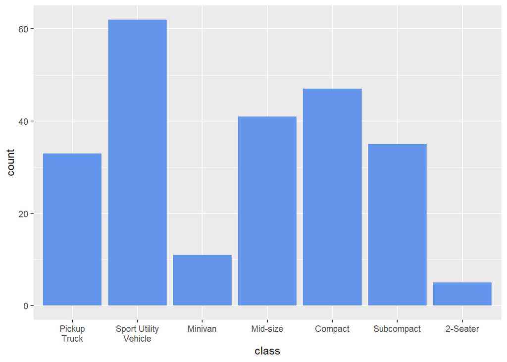

```r
ggplot(data=mpg, mapping=aes(x=class)) +
  geom_bar(fill="cornflowerblue") +

  # Change the order of classes and change the label names
  scale_x_discrete(limits = c("pickup", "suv", "minivan",
                             "midsize", "compact", "subcompact",
                             "2seater"),
                   labels = c("Pickup\nTruck",
                              "Sport Utility\nVehicle",
                              "Minivan", "Mid-size", "Compact",
                              "Subcompact", "2-Seater"))
```

### Date axes

For axes with dates, we can use `scale_x_date()` or `scale_y_date()` functions. The options for customization include:

- `date_breaks`: A text or string that gives the distance between two axis ticks. For example, we can use `"2 weeks"` or `"10 years"`.
- `date_labels`: A text or string that gives the format for the date labels.

For the date formatting, the table below gives the specifications for the symbols and the output examples.

Date formats and symbols

| Symbols | Meaning | Example Output |
| --- | --- | --- |
| %d | Day in number | 01, 05, 31 |
| %a | Weekday (abbreviated) | Mon, Tue |
| %A | Weekday (unabbreviated) | Monday, Tuesday |
| %m | Month in number | 01, 05, 12 |
| %b | Month (abbreviated) | Jan, Feb |
| %B | Month (unabbreviated) | January, February |
| %y | Year in two digits | 00, 07, 25 |
| %Y | Year in four digits | 2000, 2007, 2025 |

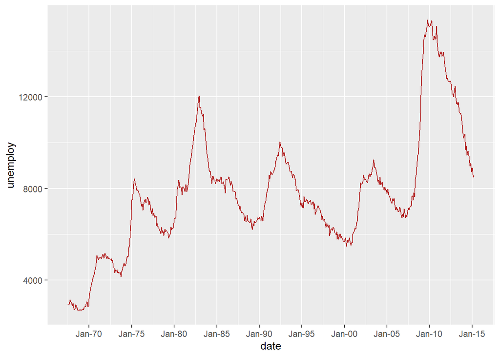

```r
ggplot(data=economics, mapping=aes(x = date, y = unemploy)) +
  geom_line(color="firebrick") +

  # Set tick marks to every 5 years
  # Use 'abbreviated month'-'two digit year' (eg Jan-70)
  scale_x_date(date_breaks = "5 years",
               date_labels = "%b-%y")
```

## Colors

Colors of points, rectangles, lines, and event scales can be changed in R and ggplot2. Using colors can make the graphs more pleasing and easier to read.

### Choosing color manually

To choose a color manually, we can use `color="colorname"` as the argument for the geom functions. In some geom functions, we can also use `fill="colorname"` option for filling bars, rectangles, the inside of point characters, and so on.

To display all available color names, you can run the `colors()` function. You can also use hexcode when specifying color, for example `color="#121212"`.

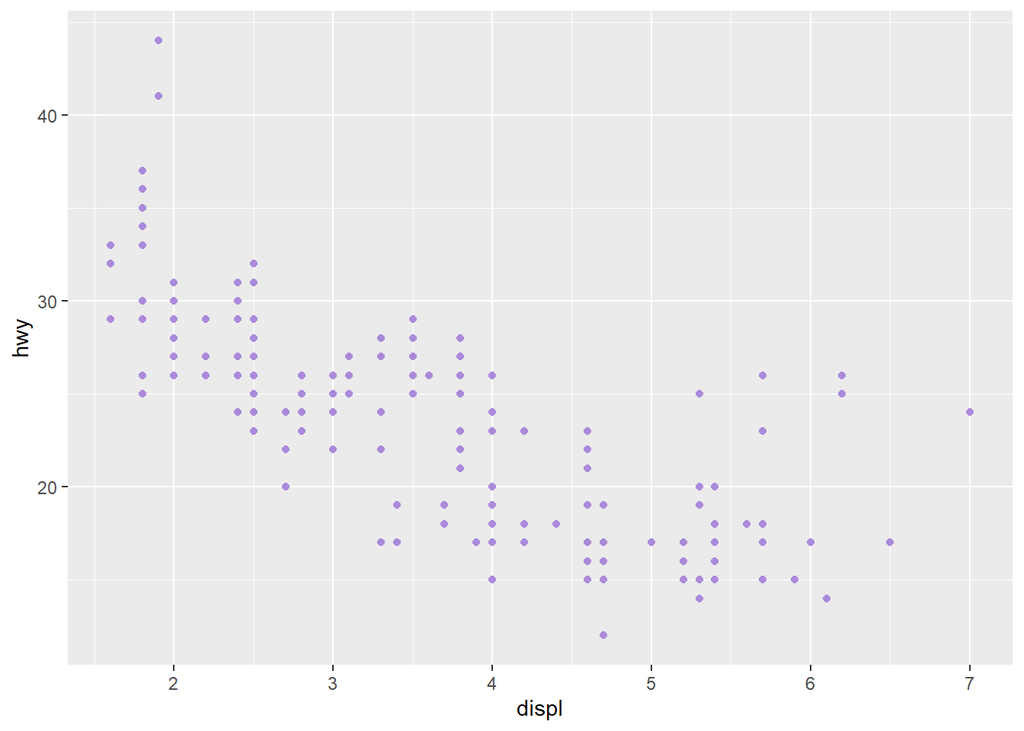

```r
ggplot(data=mpg, mapping=aes(x=displ, y=hwy)) +

  # Use the #ab8adb hexcode color
  geom_point(color="#ab8adb")
```

If you have groups or categorical variables, you can also specify the colors in vector forms.

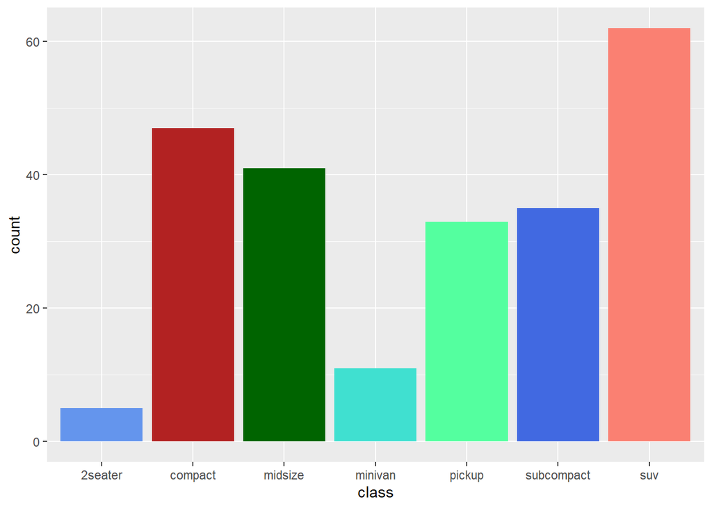

```r
ggplot(data=mpg, mapping=aes(x=class)) +

  # Use the colors for each respective category
  geom_bar(fill=c("cornflowerblue", "firebrick", "darkgreen", "turquoise",
                  "seagreen1", "royalblue", "salmon"))
```

And if you have data with levels, you can use `scale_color_manual()` and `scale_fill_manual()` functions to change the colors associated with the levels

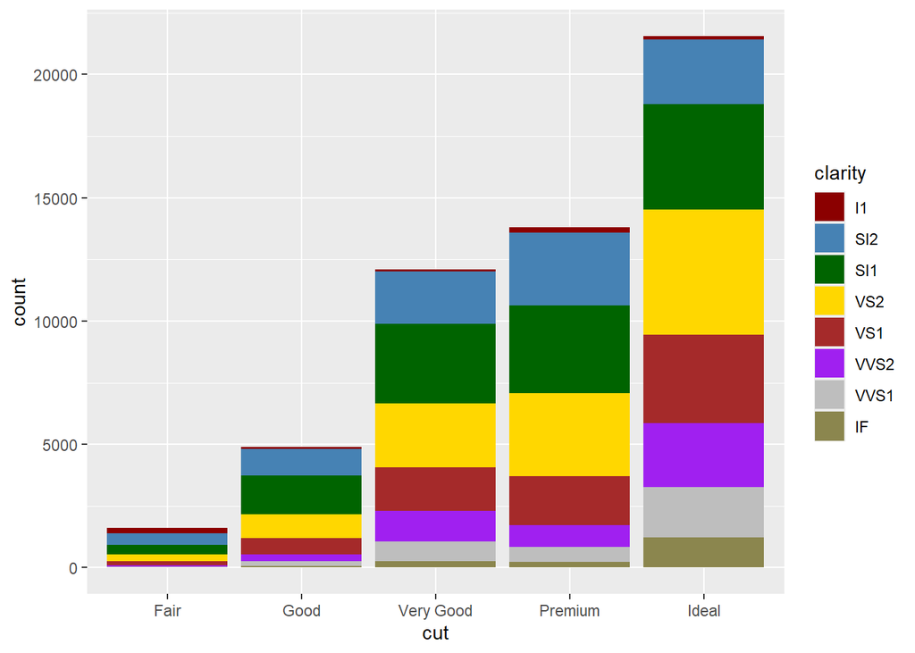

```r
ggplot(data=diamonds, mapping=aes(x = cut, fill = clarity)) +
  geom_bar() +

  # Use the colors for the levels for fill
  scale_fill_manual(values = c("darkred", "steelblue",
                               "darkgreen", "gold",
                               "brown", "purple",
                               "grey", "khaki4"))
```

### Color palettes

Specifying each individual colors can be a difficult and challenging task. To simplify this process, we can use the available color palettes available in R.

One of the common color palettes used is the ColorBrewer palettes. It is available in the `RColorBrewer` package and is included in the `ggplot2` package.

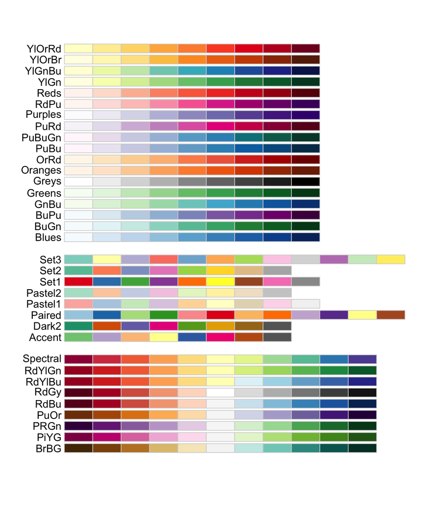

ColorBrewer color palettes

To use the ColorBrewer palettes, use the `scale_color_brewer()` or `scale_fill_brewer()` functions. We can also add the argument `direction=-1` to reverse the color direction in the palette.

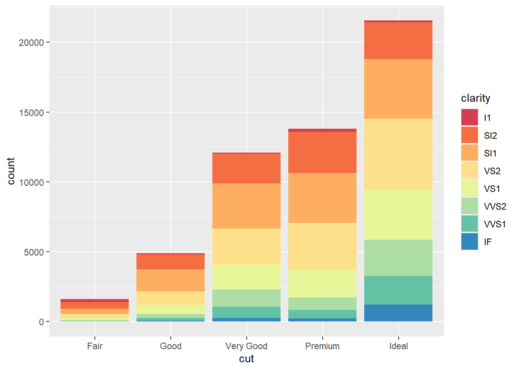

```r
ggplot(diamonds, aes(x = cut, fill = clarity)) +
  geom_bar() +

  # Use ColorBrewer (spectral) palette for fill
  scale_fill_brewer(palette = "Spectral")
```

Another popular color palette is the viridis color palette. It is also available in the `viridis` package but also included in the `ggplot2` package.

To use this color palette, we can use `scale_color_viridis_c()` and `scale_fill_viridis_c()` for continuous scales, or `scale_color_viridis_d()` and `scale_fill_viridis_d()` for discrete (or categorical) scales.

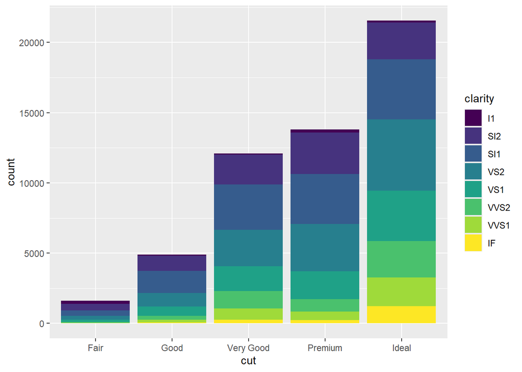

```r
ggplot(data=diamonds, mapping=aes(x = cut, fill = clarity)) +
  geom_bar() +

  # Use viridis color palette for fill
  scale_fill_viridis_d()
```

You can change to similar color palettes to viridis using the mentioned functions together with the `option` argument.

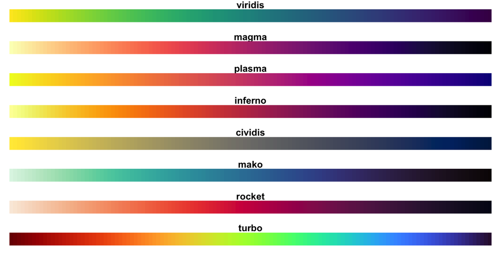

Color scale alternatives to viridis

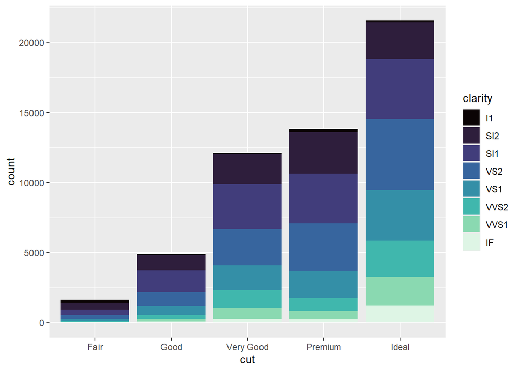

```r
ggplot(data=diamonds, mapping=aes(x = cut, fill = clarity)) +
  geom_bar() +

  # Use mako color palette for fill
  scale_fill_viridis_d(option="mako")
```

## Points and Lines

### Points

By default, the point character or shape used is the filled circle. The point chape used when can be changed using the `shape` argument in the `geom_point()` function. Below are the shapes corresponding to the numerical value associated with the `shape` argument. Note that shapes 21 to 25 can be filled with colors.

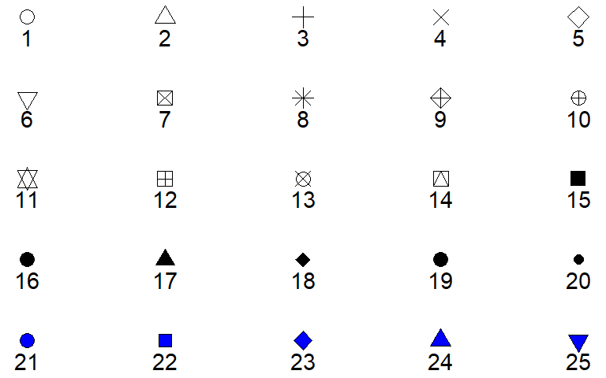

Values for point shapes

Additionally, the size of the points can be modified using `size` argument in the `geom_point()` function.

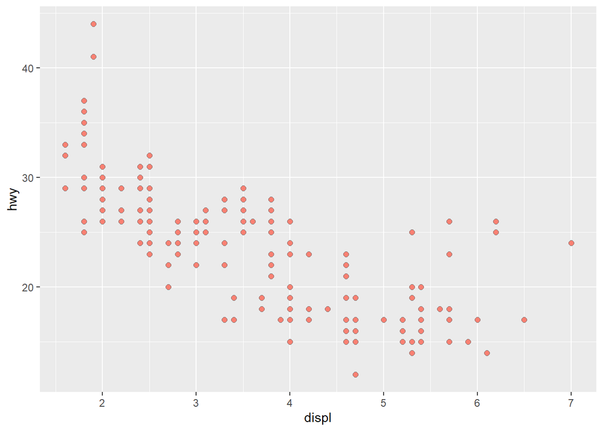

```r
ggplot(data=mpg, mapping=aes(x=displ, y=hwy)) +

  # Use cicle with fill (shape=21), change color, fill and size
  geom_point(shape=21,
             color="grey50",
             fill="salmon",
             size=2)
```

### Lines

The regular solid line is used by default when no specification is used. To change the line type in ggplot2, we can use the `linetype` argument in the `geom_line()` function or other similar functions. Below are corresponding line types and their numerical values.

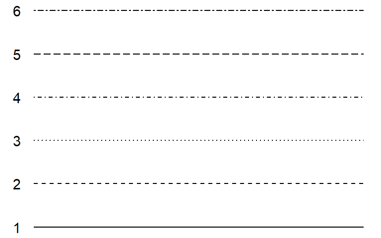

Line types

The line width can also be modified using the `linewidth` argument.

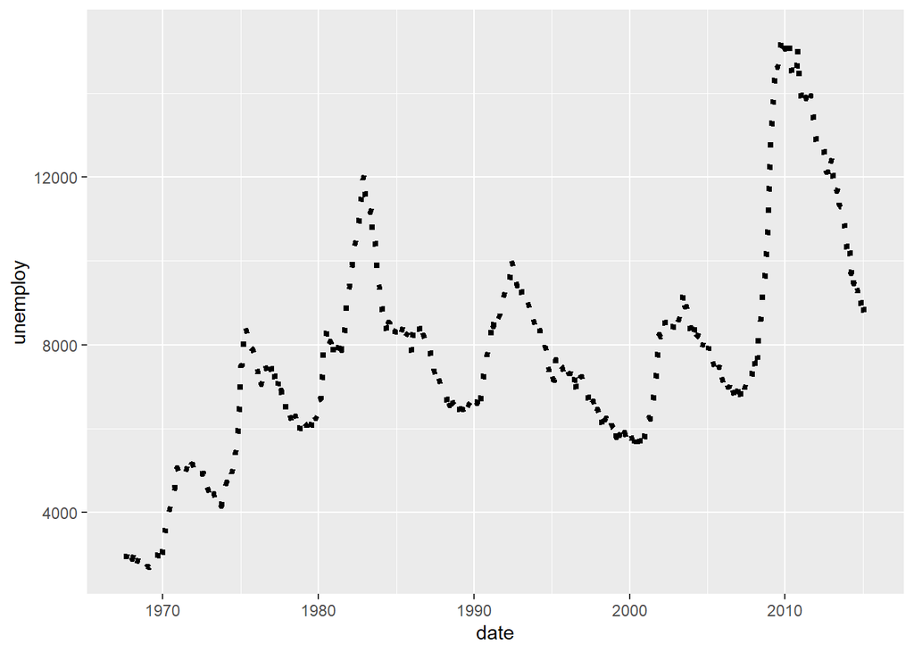

```r
ggplot(data=economics, mapping=aes(x = date, y = unemploy)) +

  # Use dotted line type and 1.5 line width
  geom_line(linetype=3,
            linewidth=1.5)
```

## Legends

Legends are automatically added when variables are mapped to the color, fill, linetype, shape, size, or alpha in the `aes()` mapping. We can modify the position of the legend using the `theme()` function, and change the legend title using the `labs()` function.

By default, legends are placed on the right side of the graph. But we can change the legend position by using the `legend.position` argument inside the `theme()` function.

Legend position options

| Position | Location |
| --- | --- |
| `"top"` | Top of the graph |
| `"bottom"` | Bottom of the graph |
| `"right"` | Right side of the graph |
| `"left"` | Left side of the graph |
| `c(x, y)` | At the specified x-y position. The x and y values must be between 0 and 1. `c(0,0)` represents the bottom-left position and `c(1,1)` represents the top-right position. |
| `"none"` | Hide the legend |

As for the legend title, we can modify this using the `labs()` function. If the legend is mapped to the color, we use `color` argument in the function. Similarly, if the legend is mapped to fill, we use `fill` argument.

The alignment of the legend title can also be modified using `legend.title.align` argument in the `theme()` function with 0 being left-aligned, 0.5 being center-aligned, and 1 being right-aligned. The title position relative to the legend can also be changed using the `legend.title.position` argument.

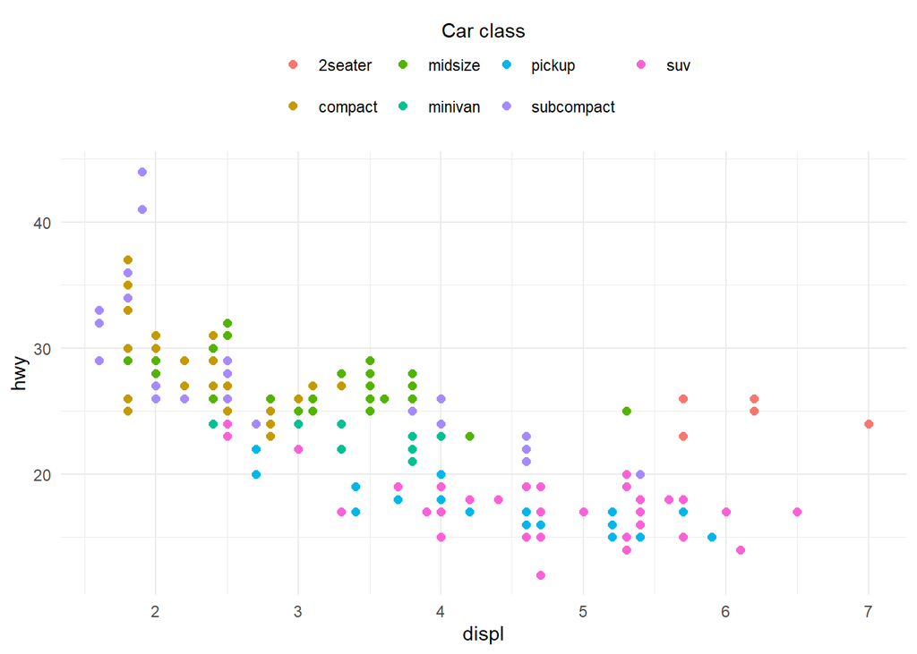

```r
ggplot(data=mpg, mapping=aes(x=displ, y=hwy, color=class)) +
  geom_point(size = 2) +
  labs(color="Car class") +
  theme_minimal() +

  theme(legend.position = "top",        # Set legend at top
        legend.title.position = "top",  # Set legend title at top of legend
        legend.title.align = 0.5)       # Set legend title to be center-aligned
```

## Axis, Legend, and Plot Labels

The `labs()` function can be used to change the modify the axis, legend, and plot labels. Here are the argument inside of the function and its use.

Arguments and options for `labs()`

| Argument/Option | Use |
| --- | --- |
| `title` | Title of the plot |
| `subtitle` | Subtitle of the plot |
| `caption` | Caption of the plot (at the bottom right by default) |
| `x` | x-axis label |
| `y` | y-axis label |
| `color` | Legend title for color |
| `fill` | Legend title for fill |
| `size` | Legend title for size |

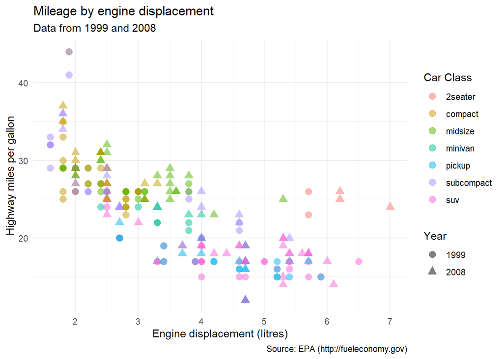

```r
ggplot(data=mpg,
       mapping=aes(x=displ, y=hwy,
                   color=class,
                   shape=factor(year))) +
  geom_point(size = 3, alpha = .5) +
  labs(title = "Mileage by engine displacement",         # Change title
       subtitle = "Data from 1999 and 2008",             # Change subtitle
       caption = "Source: EPA (http://fueleconomy.gov)", # Change caption
       x = "Engine displacement (litres)",               # Change x-axis label
       y = "Highway miles per gallon",                   # Change x-axis label
       color = "Car Class",                              # Change color legend title
       shape = "Year") +                                 # Change shape legend title
  theme_minimal()
```

## Annotations

Annotations are used when you draw additional text or lines on the graph to highlight certain things. They can be great if used carefully, but may cause the end result to be too cluttered and busy if not used properly

### Adding texts to label values

Text can be added in ggplot2 to label values using the `geom_text()` and `geom_label()` functions with the later having a background rectangle behind the text, but the two are functionally the same. Adding labels to points on the graph can be useful if we want to identify them.

The `geom_text()` and `geom_label()` require the x and y position in the `aes()` mapping for the position of the text. Additionally, the `label` argument is also required for the text that will be added at the specified position.

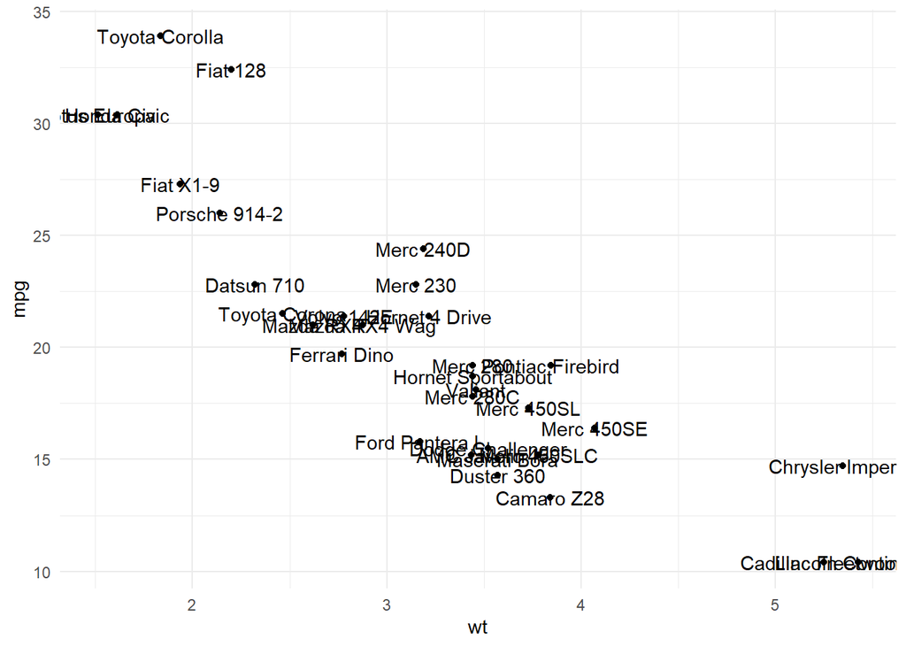

```r
ggplot(data=mtcars, mapping=aes(x=wt, y=mpg)) +
  geom_point() +

  # Add labels at the x-y position
  geom_text(label = row.names(mtcars)) +

  theme_minimal()
```

As we can see in the plot above, the added labels causes the plot to be too busy and hard to read. We can overcome this by using the `ggrepel` package and the `geom_text_repel()` and `geom_label_repel()` functions included in the package. These functions forces texts and labels not to overlap each other.

Additionally, we can reduce the size of the text using the `size` argument. You can also use the `color` and `alpha` arguments or options for further customization.

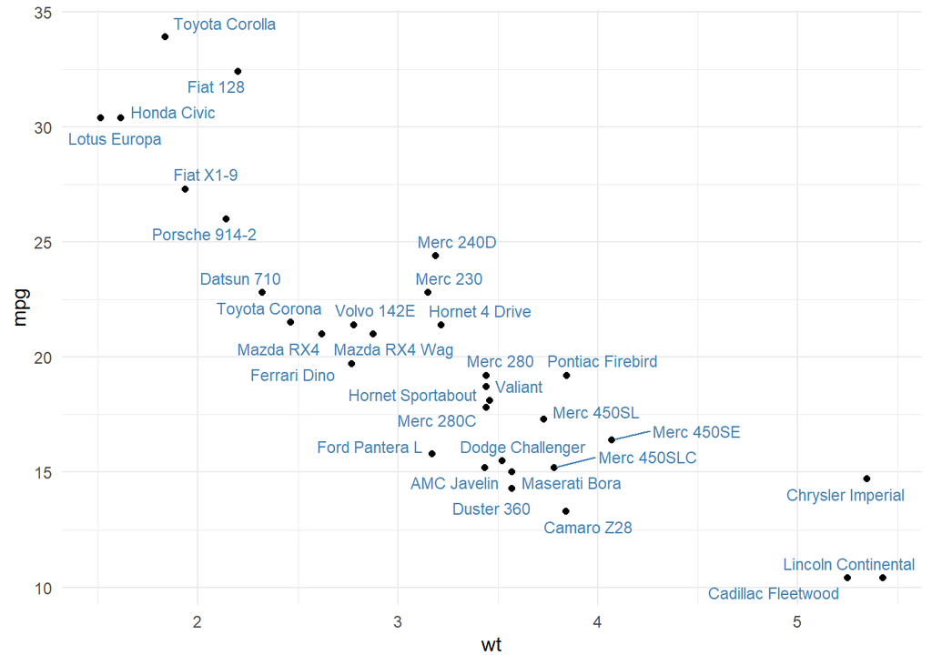

```r
library(ggrepel)

ggplot(data=mtcars, mapping=aes(x=wt, y=mpg)) +
  geom_point() +

  # Add labels at the x-y position that do not overlap
  geom_text_repel(label=row.names(mtcars),
                  size=3,
                  color="steelblue") +

  theme_minimal()
```

### Adding texts to describe plot

Another use case for adding text on a graph is to add additional information and description regarding the plot. We can use the `annotate()` function to do this with the `geom` or the first argument being `"text"`. The function also requires `x`, `y`, and `label` arguments for the x-y position and the text.

By default, the text will be center-aligned. We can change the alignment using `hjust` argument (0=left-aligned, 0.5=center-aligned, 1=right-aligned). The alignment will use the specified x-y position as the reference point. Additionally, the `vjust` argument can be used to change the vertical position of the text with respect to the x-y position (0=above, 0.5=centered, 1=below).

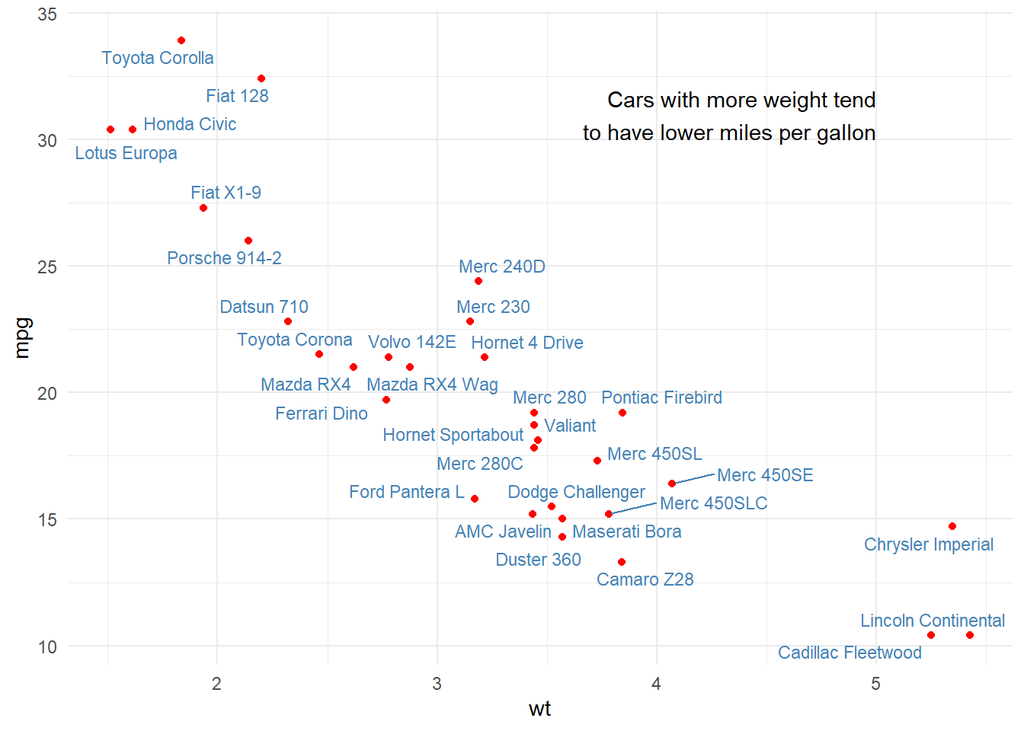

```r
sample_text <- "Cars with more weight tend\nto have lower miles per gallon"

ggplot(data=mtcars, mapping=aes(x=wt, y=mpg)) +
  geom_point(color="red") +
  geom_text_repel(label=row.names(mtcars),
                  size=3,
                  color="steelblue") +

  # Add 'sample_text' text at the x-y position
  # Make it right-aligned and above the x-y position
  annotate(geom="text", label=sample_text,
           x=5, y=30,
           hjust=1, vjust=0) +

  theme_minimal()
```

### Adding vertical or horizontal lines

In some cases, we might want to add horizontal or vertical lines. For example, if we want to compare the data that we plot to a given reference value, we can draw horizontal or vertical line for the reference value.

We can add horizontal and vertical lines using `geom_hline()` and `geom_vline()`, respectively. We can also add other options such as the line type, line width, and colors, similar to the ones used in `geom_line()`.

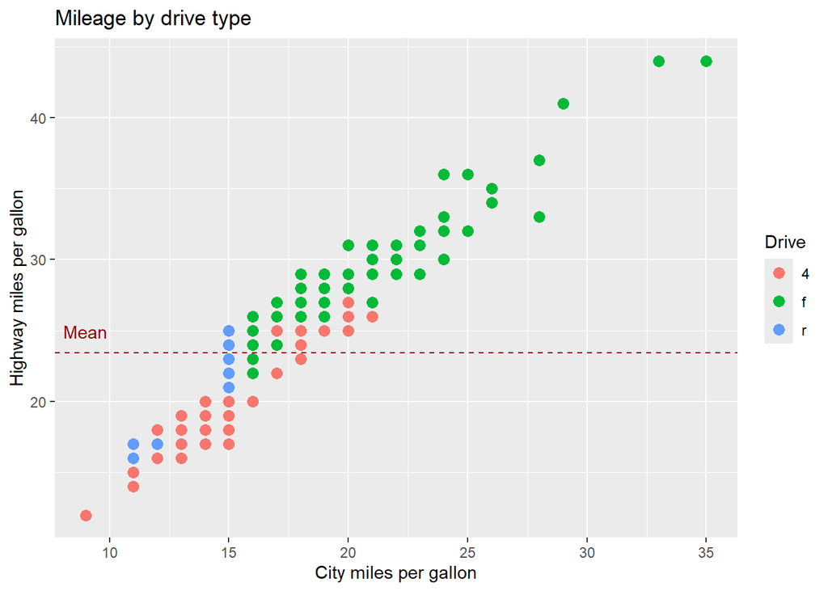

```r
mean_hwy <- mean(mpg$hwy)
ggplot(data=mpg,
       mapping=aes(x=cty, y=hwy, color=drv)) +
  geom_point(size=3) +

  # Add horizontal line at mean_hwy
  geom_hline(yintercept=mean_hwy,
             color="darkred",
             linetype = "dashed") +

  # Add text above horizontal line
  annotate(geom="text",
           x=9,
           y=mean_hwy + 1.5,
           label="Mean",
           color="darkred") +

  labs(title = "Mileage by drive type",
       x = "City miles per gallon",
       y = "Highway miles per gallon",
       color = "Drive")
```

### Highlighting selected group

Sometimes, we want to focus the audience’s attention to a single group. We can use the `gghighlight()` function in the `gghighlight` package for this.

In the example below, we want to highlight the `midsize` class. The color specified in `geom_point()` is used just for the selected `midsize` class only.

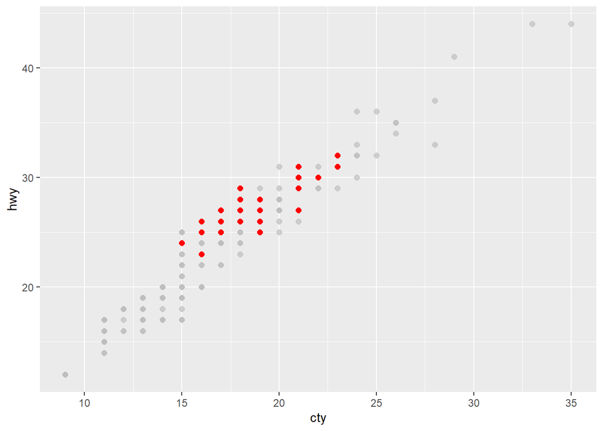

```r
# install.packages("gghighlight")
library(gghighlight)

ggplot(data=mpg, mapping=aes(x=cty, y=hwy)) +
  geom_point(color="red",
             size=2) +

  # Highlight the midsize class
  gghighlight(class=="midsize")
```

Similarly for the plot below.

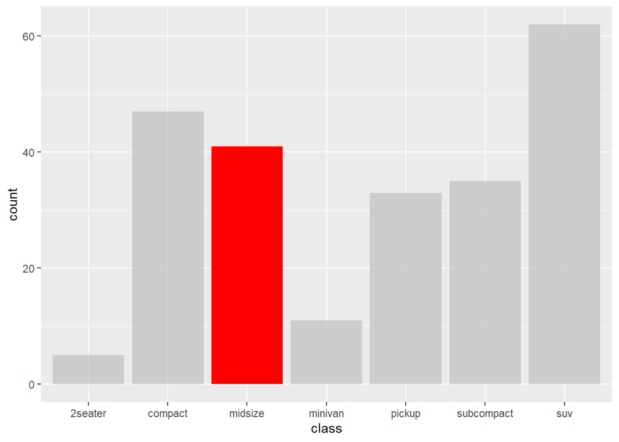

```r
ggplot(data=mpg, mapping=aes(x = class)) +
  geom_bar(fill="red") +

  # Highlight the midsize class
  gghighlight(class=="midsize")
```

## Combining Graphs

In some cases, you may want to combine several graphs into a single plot or image. You can do this using the `patchwork` package which expands ggplot2 for combining multiple plots.

After installing and loading the package, we first need to save the individual plot as an object. Then, we can use mathematical operators to combine them. For example, using the `+` or `|` operators between two ggplot objects will make the two plots side-by-side on the same row.

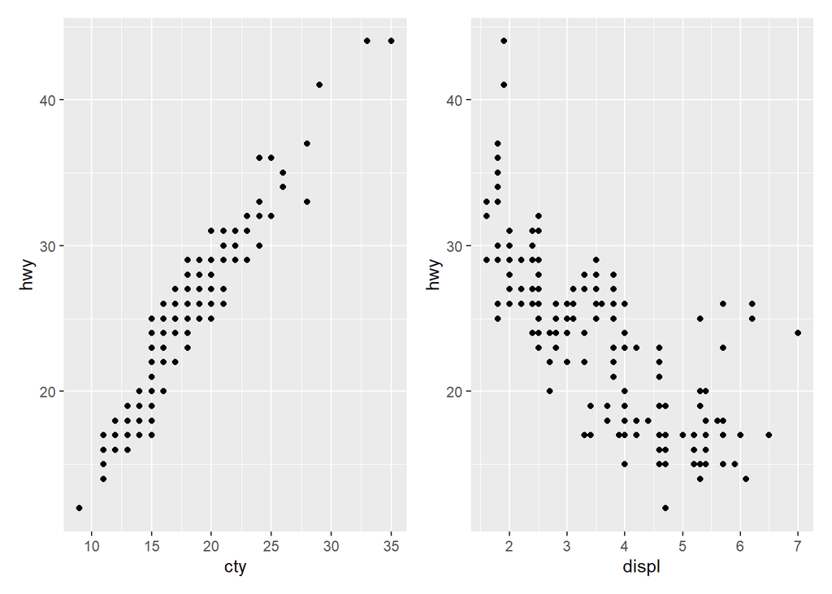

```r
# install.packages("patchwork")
library(patchwork)

# Save first plot as an object
p1 <- ggplot(data=mpg, mapping=aes(x=cty, y=hwy)) + geom_point()

# Save second plot as an object
p2 <- ggplot(data=mpg, mapping=aes(x=displ, y=hwy)) + geom_point()

# Combine first and second plot side-by-side
p1+p2
```

Using `/` operator on the other hand signifies the start of the next row.

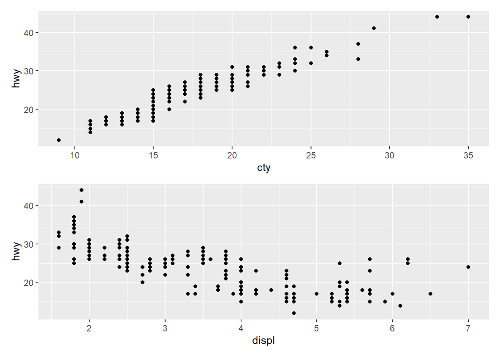

```r
# Save first plot as an object
p1 <- ggplot(data=mpg, mapping=aes(x=cty, y=hwy)) + geom_point()

# Save second plot as an object
p2 <- ggplot(data=mpg, mapping=aes(x=displ, y=hwy)) + geom_point()

# Combine first and second plot with first plot on top of second plot
p1/p2
```

We can also use multiple operators to combine multiple graphs into one plot. Additionally, after combining the plots, we can use the `&` operator which applies a function to all graphs. In the example below, we apply both `theme_minimal()` and `gghighlight()` function for all three graphs. We also used `plot_annotation()` function from the `patchwork` package to add title to the entire plot.

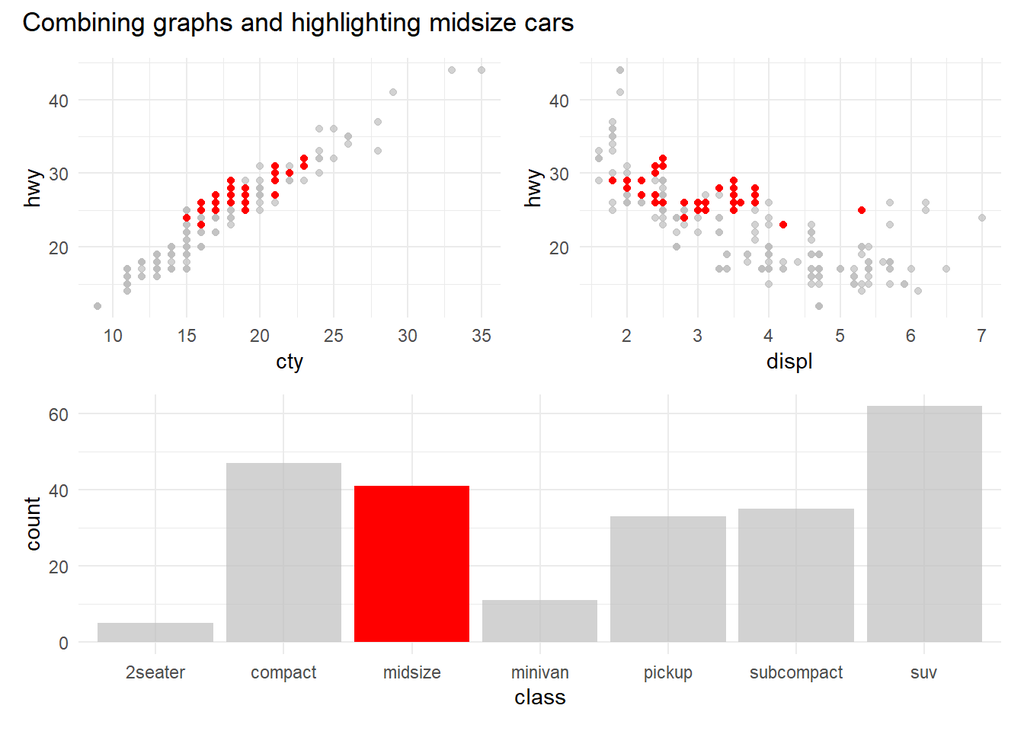

```r
# install.packages("patchwork")
library(patchwork)

# Save three different plots
p1 <- ggplot(data=mpg, mapping=aes(x=cty, y=hwy)) +
  geom_point(color="red")
p2 <- ggplot(data=mpg, mapping=aes(x=displ, y=hwy)) +
  geom_point(color="red")
p3 <- ggplot(data=mpg, mapping=aes(x = class)) +
  geom_bar(fill="red")

# Combine the three plots
(p1 | p2) / p3 &

  # Apply theme_minimal() to every plot
  theme_minimal() &

  # Highlight midsize class in every plot
  gghighlight(class=="midsize") &

  # Add title to the combined plot
  plot_annotation(title="Combining graphs and highlighting midsize cars")
```

## Conclusion

In this topic, we have explored various ways we can use to further customize graphs produced using ggplot2. At the end of the day, the use case scenario for these additional customization depends on what you want to achieve. For example, highlighting a single group out of the rest may be useful if you want to focus on the group, or adding text on the graph can be useful if you want to add information. However, over-customization can also be a problem and cause the plot to be too busy.